# Sentiment Analysis of the UK Government’s Public Releases for COVID-19

R Corrigan

7/11/2021

### Announcement Frequency

The following plot stack shows how the number of weekly announcements increased as the infection first began to spread throughout the UK.

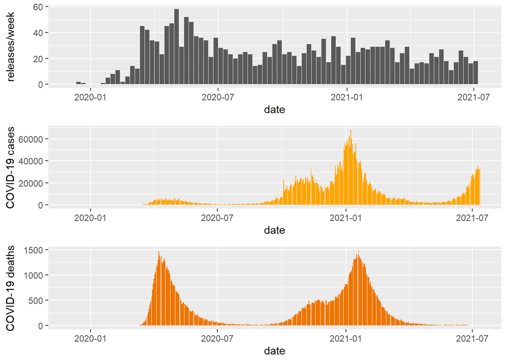

### Sentiment

Sentiment was analyzed using the AFINN lexicon of tidytext package. Net sentiment for virtually all news releases was found to be neutral or positive. Although 97 organizations contributed releases to the web page, only a fraction of these contributed routinely. Considering only organizations with at least 10 news releases, the average net sentiment across the organizations was quite variable as shown below:

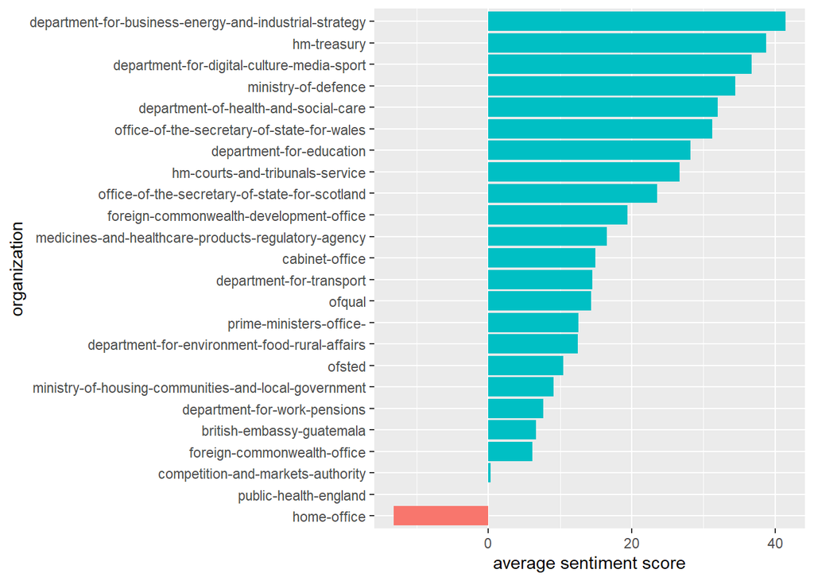

Only the government’s Home Office department (responsible for immigration and passports, drugs policy, crime, fire, counter-terrorism and police) had net negative sentiment. All others were positive, except for Public Health England which was neutral overall (i.e., average net sentiment of 0).

Over the analyzed time period, sentiment of the news releases trended either relatively flat or upward, but not downward. This can be seen in the stacked time series plots for average sentiment (averaged over a week) of the news releases and COVID-19 death counts in the UK below.

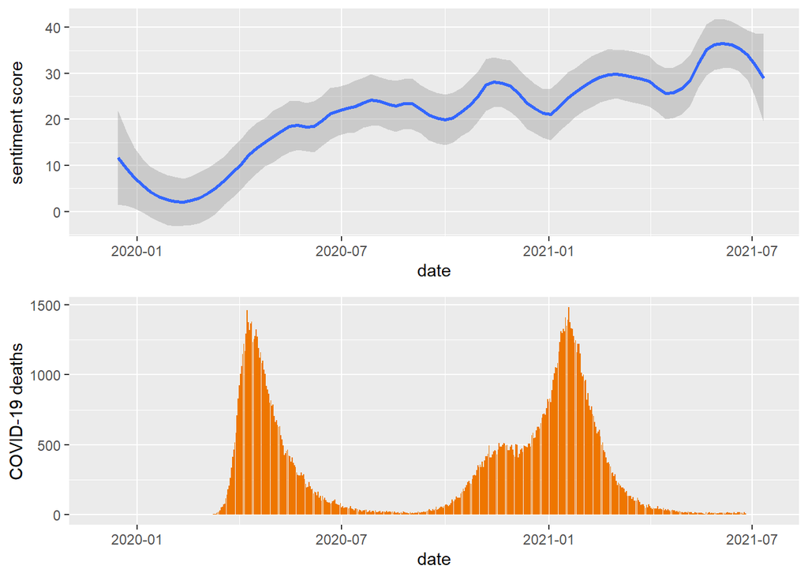

The tidytext AFINN lexicon assigns sentiment integer scores ranging from -5 (monst negative) to +5 (most positive) to words. The plot below shows the five most prevalent words in the public releases assigned to each of the 10 possible sentiment scores.

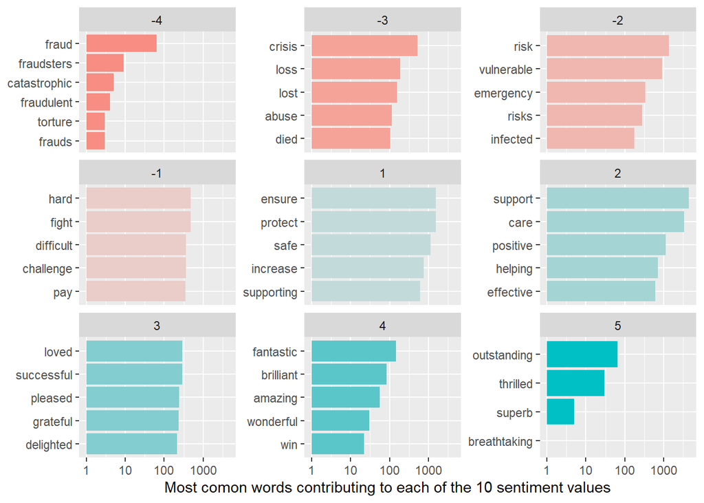

[^1]: Scraping was done with the rvest package
[^2]: Sentiment analysis used the tidytext package